# Jupyter Notebook integration test

Nes, Rasmus true  
04-18-2021

Distill is a publication format for scientific and technical writing, native to the web.

Learn more about using Distill at https://rstudio.github.io/distill.

```python
import math

import matplotlib.pyplot as plt
import numpy as np
import pandas as pd

plt.rcParams["figure.figsize"] = [15, 7]
```

## Imports

```python
customers = pd.read_csv("Archive/customers.csv")
order_lines = pd.read_csv("Archive/order_lines.csv")
products = pd.read_csv("Archive/products.csv")
zip_places = pd.read_csv("Archive/zip_places.csv")
```

```python
# Join data
order_products = pd.merge(order_lines, products, on="product_id")
order_products["delivery_date"] = pd.to_datetime(order_products["delivery_date"])
order_products["delivery_week"] = (
    order_products["delivery_date"].dt.to_period("W").apply(lambda r: r.start_time)
)
```

```python
order_products
```

|  | order_id | customer_id | delivery_date | is_delivery | zip_place | product_id | quantity | net_unit_price | is_from_recipe | is_from_product_list | product_name | main_category | sub_category | brand | delivery_week |
| --- | --- | --- | --- | --- | --- | --- | --- | --- | --- | --- | --- | --- | --- | --- | --- |
| 0 | b5bd36902333660e728adbca18e72db305028c00 | 42d70c111366c2e57877a60da9482448c16a92c2 | 2018-01-01 | True | Oslo | 20329 | 1.0 | 45.22 | False | False | Helios Fullkornris Lang 700.00 g | Middager og tilbehør | Ris og gryn | Helios | 2018-01-01 |
| 1 | 6ef34c7dd4cad0434a552c322b6754d7502b9bde | f7e39cc322a01e357c9e9e4c90dd660dcfefe136 | 2018-03-12 | True | Vinterbro | 20329 | 1.0 | 45.22 | False | False | Helios Fullkornris Lang 700.00 g | Middager og tilbehør | Ris og gryn | Helios | 2018-03-12 |
| 2 | 3210c4fd4d8e8ec894fad6638389585dee0c73b0 | dc290c4c4245b2d3242f59f214cd20b136f9134c | 2018-04-18 | False | Oslo | 20329 | 1.0 | 45.22 | False | False | Helios Fullkornris Lang 700.00 g | Middager og tilbehør | Ris og gryn | Helios | 2018-04-16 |
| 3 | 3d9cb6cb5146bf5e3841016e1144d7dd418f81a6 | 2a795bec85389cd74c7b2a0be9032eeda42dc65e | 2018-05-28 | False | Oslo | 20329 | 1.0 | 45.22 | False | False | Helios Fullkornris Lang 700.00 g | Middager og tilbehør | Ris og gryn | Helios | 2018-05-28 |
| 4 | a26da49bf193ead0fdb86d7e949b5d3887e8caeb | 2a795bec85389cd74c7b2a0be9032eeda42dc65e | 2018-08-05 | False | Oslo | 20329 | 1.0 | 46.09 | False | False | Helios Fullkornris Lang 700.00 g | Middager og tilbehør | Ris og gryn | Helios | 2018-07-30 |
| … | … | … | … | … | … | … | … | … | … | … | … | … | … | … | … |
| 262286 | fa31252e60f895ba4d6a62bf1d7aa0b000f6dc45 | de93f96e96c8652ee2bd410ded22c161a8b9f668 | 2018-12-31 | True | Oslo | 27470 | 1.0 | 112.96 | False | False | Superlife Topping Tranebær Økologisk 200.00 g | Brød og frokostblandinger | Frokostblandinger og gryn | Superlife | 2018-12-31 |
| 262287 | e3fa57a97071cbe8aafd21f192696ae541e21920 | f5afa34b23f76f31cf1f21cca492683b525b69bd | 2018-12-31 | True | Oslo | 14854 | 1.0 | 29.92 | False | False | Yatzy i Eske Med 6 Terninger 1.00 stk | Husholdning og tekstil | Diverse husholdning | NaN | 2018-12-31 |
| 262288 | 571b7c2f70357404fbe1b748b1a0c33e0906798e | 737323a66ab8d73c6d428735e42bee317d2c8feb | 2018-12-31 | True | Løvenstad | 1125 | 1.0 | 49.52 | False | False | Weifa Paracet Mikstur 24mg 60.00 ml | Legemidler og helsekost | Legemidler | Weifa | 2018-12-31 |
| 262289 | 571b7c2f70357404fbe1b748b1a0c33e0906798e | 737323a66ab8d73c6d428735e42bee317d2c8feb | 2018-12-31 | True | Løvenstad | 23564 | 1.0 | 32.96 | False | False | FestligeTing Sugerør Blå 24.00 stk | Barneprodukter | Bursdag | FestligeTing | 2018-12-31 |
| 262290 | 571b7c2f70357404fbe1b748b1a0c33e0906798e | 737323a66ab8d73c6d428735e42bee317d2c8feb | 2018-12-31 | True | Løvenstad | 21049 | 1.0 | 29.12 | False | False | Hansa Borg Borg Østlandets Gull 0.50 l | Øl, cider og rusbrus | Øl | Hansa Borg | 2018-12-31 |

262291 rows × 15 columns

# Exploratory data analysis

```python
order_products.nunique()
```

```
order_id                8580
customer_id              946
delivery_date            359
is_delivery                2
zip_place                100
product_id              5978
quantity                  42
net_unit_price          3490
is_from_recipe             2
is_from_product_list       2
product_name            5977
main_category             32
sub_category             182
brand                    525
delivery_week             52
dtype: int64
```

```python
order_products.dtypes
```

[output not shown]

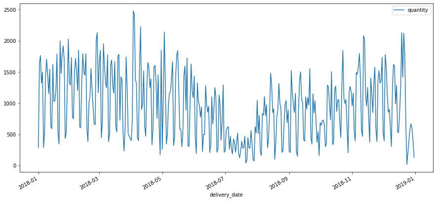

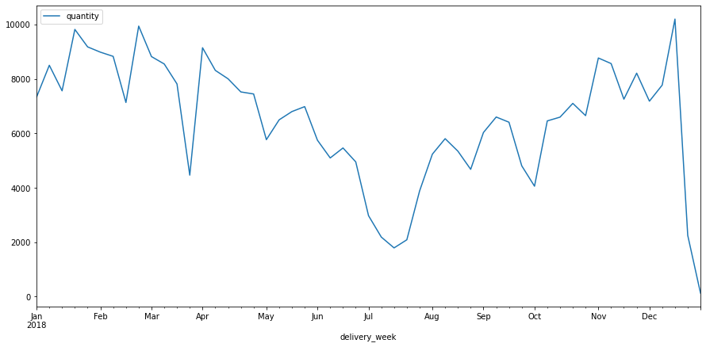

```python
# Sum of all products by day and week
order_products.groupby("delivery_date").agg(quantity=("quantity", "sum")).plot()
order_products.groupby("delivery_week").agg(quantity=("quantity", "sum")).plot()
```

```python
def plot_product_quantity(
    product_id, group="product_name", time_agg="delivery_date", df=order_products
):
    df_prod = df.query("product_id == @product_id")
    category = df_prod[group].iloc[0]

    if group == "product_name":
        df_q = df_prod
    elif group == "main_category":
        df_q = df.query("main_category == @category")
    elif group == "sub_category":
        df_q = df.query("sub_category == @category")
    else:
        raise Exception("Invalid `group` parameter.")

    df_plot = df_q.groupby(time_agg).agg(n=("quantity", "sum"))

    if time_agg == "delivery_date":
        idx = pd.date_range("2018-01-01", "2018-12-31")
        df_plot.index = pd.DatetimeIndex(df_plot.index)
        df_plot = df_plot.reindex(idx, fill_value=0)

    return df_plot.rename(columns={"n": category}).plot()
```

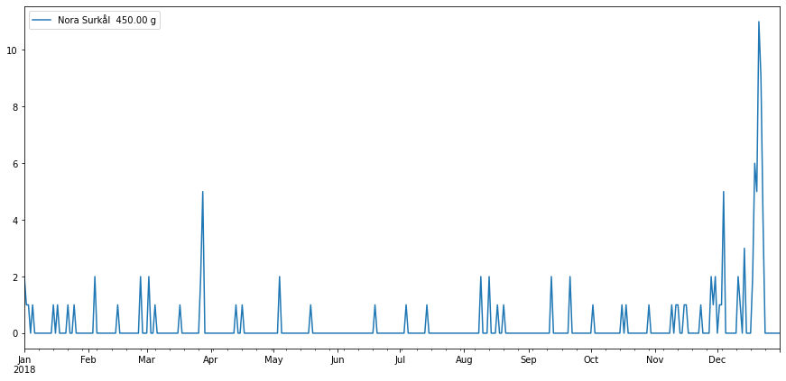

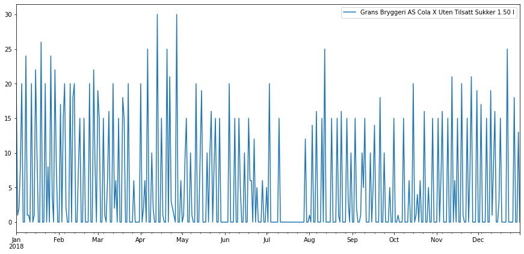

```python
plot_product_quantity(987)
plot_product_quantity(16534)
```

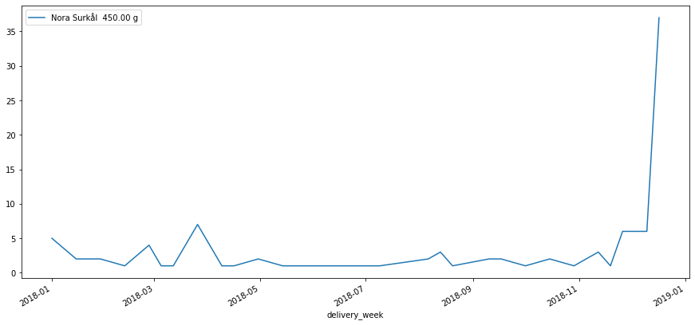

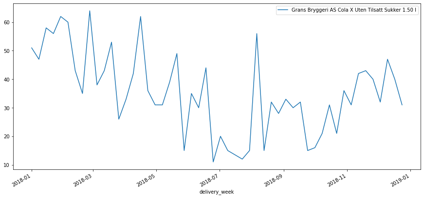

```python
## Aggregate per week
plot_product_quantity(987, time_agg="delivery_week")
plot_product_quantity(16534, time_agg="delivery_week")
```

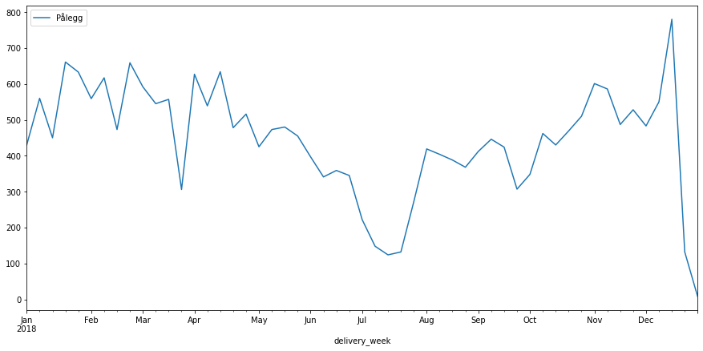

```python
plot_product_quantity(
    products.sample().product_id.iloc[0],
    group="main_category",
    time_agg="delivery_week",
)
```

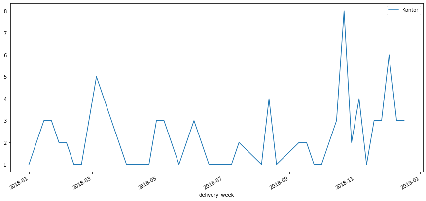

```python
plot_product_quantity(
    products.sample().product_id.iloc[0],
    group="sub_category",
    time_agg="delivery_week",
)
```

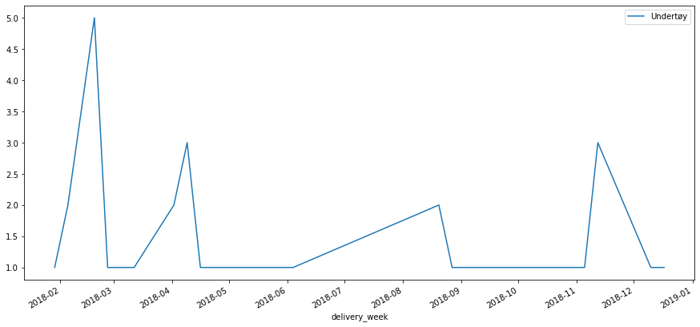

```python
plot_product_quantity(
    products.sample().product_id.iloc[0],
    group="sub_category",
    time_agg="delivery_week",
)
```

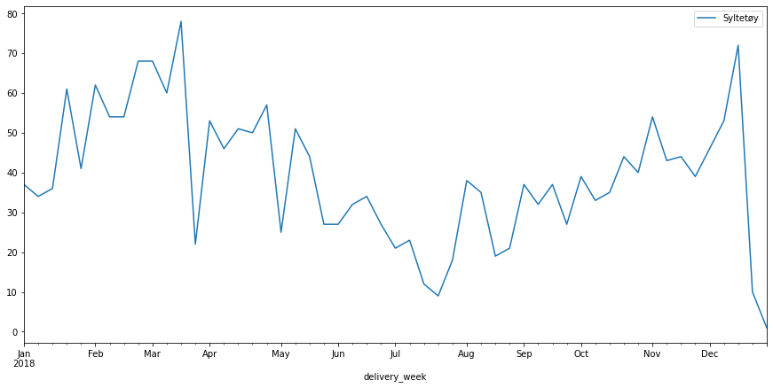

```python
plot_product_quantity(
    products.sample().product_id.iloc[0],
    group="sub_category",
    time_agg="delivery_week",
)
```

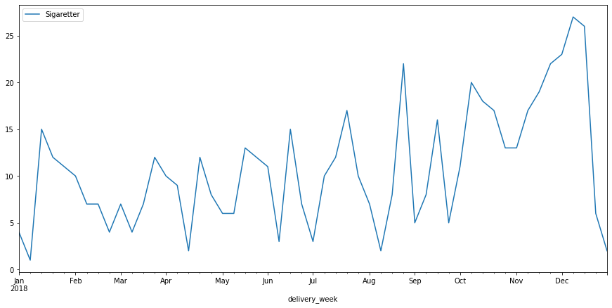

```python
plot_product_quantity(
    products.sample().product_id.iloc[0],
    group="sub_category",
    time_agg="delivery_week",
)
```

# Prepare data for Hierarchical model

```python
order_products
```

|  | order_id | customer_id | delivery_date | is_delivery | zip_place | product_id | quantity | net_unit_price | is_from_recipe | is_from_product_list | product_name | main_category | sub_category | brand | delivery_week |
| --- | --- | --- | --- | --- | --- | --- | --- | --- | --- | --- | --- | --- | --- | --- | --- |
| 0 | b5bd36902333660e728adbca18e72db305028c00 | 42d70c111366c2e57877a60da9482448c16a92c2 | 2018-01-01 | True | Oslo | 20329 | 1.0 | 45.22 | False | False | Helios Fullkornris Lang 700.00 g | Middager og tilbehør | Ris og gryn | Helios | 2018-01-01 |
| 1 | 6ef34c7dd4cad0434a552c322b6754d7502b9bde | f7e39cc322a01e357c9e9e4c90dd660dcfefe136 | 2018-03-12 | True | Vinterbro | 20329 | 1.0 | 45.22 | False | False | Helios Fullkornris Lang 700.00 g | Middager og tilbehør | Ris og gryn | Helios | 2018-03-12 |
| 2 | 3210c4fd4d8e8ec894fad6638389585dee0c73b0 | dc290c4c4245b2d3242f59f214cd20b136f9134c | 2018-04-18 | False | Oslo | 20329 | 1.0 | 45.22 | False | False | Helios Fullkornris Lang 700.00 g | Middager og tilbehør | Ris og gryn | Helios | 2018-04-16 |
| 3 | 3d9cb6cb5146bf5e3841016e1144d7dd418f81a6 | 2a795bec85389cd74c7b2a0be9032eeda42dc65e | 2018-05-28 | False | Oslo | 20329 | 1.0 | 45.22 | False | False | Helios Fullkornris Lang 700.00 g | Middager og tilbehør | Ris og gryn | Helios | 2018-05-28 |
| 4 | a26da49bf193ead0fdb86d7e949b5d3887e8caeb | 2a795bec85389cd74c7b2a0be9032eeda42dc65e | 2018-08-05 | False | Oslo | 20329 | 1.0 | 46.09 | False | False | Helios Fullkornris Lang 700.00 g | Middager og tilbehør | Ris og gryn | Helios | 2018-07-30 |
| … | … | … | … | … | … | … | … | … | … | … | … | … | … | … | … |
| 262286 | fa31252e60f895ba4d6a62bf1d7aa0b000f6dc45 | de93f96e96c8652ee2bd410ded22c161a8b9f668 | 2018-12-31 | True | Oslo | 27470 | 1.0 | 112.96 | False | False | Superlife Topping Tranebær Økologisk 200.00 g | Brød og frokostblandinger | Frokostblandinger og gryn | Superlife | 2018-12-31 |
| 262287 | e3fa57a97071cbe8aafd21f192696ae541e21920 | f5afa34b23f76f31cf1f21cca492683b525b69bd | 2018-12-31 | True | Oslo | 14854 | 1.0 | 29.92 | False | False | Yatzy i Eske Med 6 Terninger 1.00 stk | Husholdning og tekstil | Diverse husholdning | NaN | 2018-12-31 |
| 262288 | 571b7c2f70357404fbe1b748b1a0c33e0906798e | 737323a66ab8d73c6d428735e42bee317d2c8feb | 2018-12-31 | True | Løvenstad | 1125 | 1.0 | 49.52 | False | False | Weifa Paracet Mikstur 24mg 60.00 ml | Legemidler og helsekost | Legemidler | Weifa | 2018-12-31 |
| 262289 | 571b7c2f70357404fbe1b748b1a0c33e0906798e | 737323a66ab8d73c6d428735e42bee317d2c8feb | 2018-12-31 | True | Løvenstad | 23564 | 1.0 | 32.96 | False | False | FestligeTing Sugerør Blå 24.00 stk | Barneprodukter | Bursdag | FestligeTing | 2018-12-31 |
| 262290 | 571b7c2f70357404fbe1b748b1a0c33e0906798e | 737323a66ab8d73c6d428735e42bee317d2c8feb | 2018-12-31 | True | Løvenstad | 21049 | 1.0 | 29.12 | False | False | Hansa Borg Borg Østlandets Gull 0.50 l | Øl, cider og rusbrus | Øl | Hansa Borg | 2018-12-31 |

262291 rows × 15 columns

```python
df_model = (
    order_products.groupby(["delivery_week", "main_category"])
    .agg(quantity=("quantity", "sum"))
    .reset_index()
    .query("delivery_week != '2018-12-31'")  # Remove last, single day of year
)
```

```python
# Add holidays by manual inspection. (Could easily be obtained in a real scenario from a calendar)
df_model["holiday"] = np.select(
    [
        df_model["delivery_week"] == "2018-02-19",  # Winter holidays
        df_model["delivery_week"] == "2018-03-26",  # Easter
        df_model["delivery_week"] == "2018-07-02",  # Summer/july holidays
        df_model["delivery_week"] == "2018-07-09",  # Summer/july holidays
        df_model["delivery_week"] == "2018-07-16",  # Summer/july holidays
        df_model["delivery_week"] == "2018-07-23",  # Summer/july holidays
        df_model["delivery_week"] == "2018-12-24",  # Christmas
    ],
    [1 for _ in range(7)],
    default=0,
)
```

```python
df_model["last_quantity"] = df_model.groupby("main_category")["quantity"].shift()
```

```python
# Skip first week due to missing 'last_quantity' and drop 'delivery_week' column
df_model = df_model.query("delivery_week != '2018-01-01'").drop(
    ["delivery_week"], axis=1
)
```

```python
df_model
```

|  | main_category | quantity | holiday | last_quantity |
| --- | --- | --- | --- | --- |
| 30 | Asiatisk | 40.0 | 0 | 48.0 |
| 31 | Barneprodukter | 315.0 | 0 | 251.0 |
| 32 | Blomster og planter | 14.0 | 0 | 4.0 |
| 33 | Brød og frokostblandinger | 498.0 | 0 | 516.0 |
| 34 | Drikkevarer | 567.0 | 0 | 412.0 |
| … | … | … | … | … |
| 1527 | Shampo, såpe og hudpleie | 7.0 | 1 | 62.0 |
| 1528 | Snacks og godteri | 192.0 | 1 | 628.0 |
| 1529 | Snus og tobakk | 16.0 | 1 | 38.0 |
| 1530 | Tørkepapir og vaskemidler | 54.0 | 1 | 294.0 |
| 1531 | Øl, cider og rusbrus | 50.0 | 1 | 218.0 |

1502 rows × 4 columns

```python
# Check number of products, sub_category and main_category
products.nunique()
```

```
product_id       5978
product_name     5977
main_category      32
sub_category      182
brand             525
dtype: int64
```

# Problem formulation

\[q_i \sim Normal(\mu_i, \sigma)\]

\[\mu_i = \alpha + \alpha_{MAIN[i]} + \alpha_{SUB[i]} + \beta_{HOLIDAY[i]}H_i + \beta_{TEMP[i]}T_i + \beta_{PRECIP[i]}P_i + \beta_{LASTQUANTITY[i]}Q_i\]

\[\alpha_{MAIN} \sim Normal(0, \sigma_{MAIN})\]

\[\alpha_{SUB} \sim Normal(0, \sigma_{SUB})\]

\[\alpha \sim Normal(0, 10)\]

\[\beta_{HOLIDAY} \sim Normal(0, \sigma_{HOLIDAY})\]

\[\beta_{TEMP} \sim Normal(0, \sigma_{TEMP})\]

\[\beta_{PRECIP} \sim Normal(0, \sigma_{PRECIP})\]

\[\beta_{LASTQUANTITY} \sim Normal(1, \sigma_{LASTQUANTITY})\]

\[\sigma_{LASTQUANTITY} \sim HalfCauchy(0, 1)\]

\[\sigma, \sigma_{SUB}, \sigma_{MAIN}, \sigma_{HOLIDAY}, \sigma_{TEMP}, \sigma_{PRECIP} \sim HalfCauchy(0, 1)\]

## Variables explained

- \(q_i\) = quantity prediction for `sub_category` \(i\)
- \(H\) = holiday indicator variable
- \(T\) = temperature (forecasted)
- \(P\) = precipation (forecasted)
- \(Q\) = quantity observed last week for `sub_category` \(i\)

## Thoughts

- Final model will certainly not look like this.
- Multivariate Normal for `TEMP` and `PRECIP`?
- Residuals can be checked in \(\sigma\)